# Bellabeat Case Study

Sankalp Roy

27-12-2025

```r
knitr::opts_chunk$set(
echo = TRUE,
warning = FALSE,
message = FALSE
)
```

## **Introduction**

Bellabeat is a high-tech wellness company that develops smart products designed to help women monitor activity, sleep, stress, and overall health. The goal of this analysis is to explore smart device usage data to uncover behavioral trends that can inform Bellabeat’s marketing strategy.

This case study follows the Ask, Prepare, Process, Analyze, Share, and Act framework.

## **Ask: Business Task**

### Objective:

Analyze smart device usage data to identify trends in activity and sleep, then translate those insights into actionable marketing recommendations for Bellabeat.

### Key Questions:

What trends exist in smart device usage?

How could these trends apply to Bellabeat customers?

How can these trends influence marketing strategy?

Prepare: Data Sources

### Primary Dataset:

FitBit Fitness Tracker Data (Kaggle, CC0 Public Domain)

Daily activity, calories, steps, and sleep

31-day observation period

Limitations:

Small sample size

No gender information

## **Process: Data Cleaning & Preparation**

Fitbit users may not reflect Bellabeat users

```r
library(tidyverse)
library(lubridate)
library(janitor)
```

## **Importing Data**

```r
daily_activity <- read_csv("dailyActivity_merged.csv") %>%
clean_names()

sleep_day <- read_csv("sleepDay_merged.csv") %>%
clean_names()

daily_calories <- read_csv("dailyCalories_merged.csv") %>%
  clean_names()
```

## **Exploring the Data**

```r
head(daily_activity)
```

```
## # A tibble: 6 × 15
##           id activity_date total_steps total_distance tracker_distance
##        <dbl> <chr>               <dbl>          <dbl>            <dbl>
## 1 1503960366 4/12/2016           13162           8.5              8.5
## 2 1503960366 4/13/2016           10735           6.97             6.97
## 3 1503960366 4/14/2016           10460           6.74             6.74
## 4 1503960366 4/15/2016            9762           6.28             6.28
## 5 1503960366 4/16/2016           12669           8.16             8.16
## 6 1503960366 4/17/2016            9705           6.48             6.48
## # ℹ 10 more variables: logged_activities_distance <dbl>,
## #   very_active_distance <dbl>, moderately_active_distance <dbl>,
## #   light_active_distance <dbl>, sedentary_active_distance <dbl>,
## #   very_active_minutes <dbl>, fairly_active_minutes <dbl>,
## #   lightly_active_minutes <dbl>, sedentary_minutes <dbl>, calories <dbl>
```

```r
glimpse(daily_activity)
```

```
## Rows: 940
## Columns: 15
## $ id                         <dbl> 1503960366, 1503960366, 1503960366, 1503960…
## $ activity_date              <chr> "4/12/2016", "4/13/2016", "4/14/2016", "4/1…
## $ total_steps                <dbl> 13162, 10735, 10460, 9762, 12669, 9705, 130…
## $ total_distance             <dbl> 8.50, 6.97, 6.74, 6.28, 8.16, 6.48, 8.59, 9…
## $ tracker_distance           <dbl> 8.50, 6.97, 6.74, 6.28, 8.16, 6.48, 8.59, 9…
## $ logged_activities_distance <dbl> 0, 0, 0, 0, 0, 0, 0, 0, 0, 0, 0, 0, 0, 0, 0…
## $ very_active_distance       <dbl> 1.88, 1.57, 2.44, 2.14, 2.71, 3.19, 3.25, 3…
## $ moderately_active_distance <dbl> 0.55, 0.69, 0.40, 1.26, 0.41, 0.78, 0.64, 1…
## $ light_active_distance      <dbl> 6.06, 4.71, 3.91, 2.83, 5.04, 2.51, 4.71, 5…
## $ sedentary_active_distance  <dbl> 0, 0, 0, 0, 0, 0, 0, 0, 0, 0, 0, 0, 0, 0, 0…
## $ very_active_minutes        <dbl> 25, 21, 30, 29, 36, 38, 42, 50, 28, 19, 66,…
## $ fairly_active_minutes      <dbl> 13, 19, 11, 34, 10, 20, 16, 31, 12, 8, 27, …
## $ lightly_active_minutes     <dbl> 328, 217, 181, 209, 221, 164, 233, 264, 205…
## $ sedentary_minutes          <dbl> 728, 776, 1218, 726, 773, 539, 1149, 775, 8…
## $ calories                   <dbl> 1985, 1797, 1776, 1745, 1863, 1728, 1921, 2…
```

```r
head(sleep_day)
```

```
## # A tibble: 6 × 5
##          id sleep_day total_sleep_records total_minutes_asleep total_time_in_bed
##       <dbl> <chr>                   <dbl>                <dbl>             <dbl>
## 1    1.50e9 4/12/201…                   1                  327               346
## 2    1.50e9 4/13/201…                   2                  384               407
## 3    1.50e9 4/15/201…                   1                  412               442
## 4    1.50e9 4/16/201…                   2                  340               367
## 5    1.50e9 4/17/201…                   1                  700               712
## 6    1.50e9 4/19/201…                   1                  304               320
```

```r
glimpse(sleep_day)
```

```
## Rows: 413
## Columns: 5
## $ id                   <dbl> 1503960366, 1503960366, 1503960366, 1503960366, 1…
## $ sleep_day            <chr> "4/12/2016 12:00:00 AM", "4/13/2016 12:00:00 AM",…
## $ total_sleep_records  <dbl> 1, 2, 1, 2, 1, 1, 1, 1, 1, 1, 1, 1, 1, 1, 1, 1, 1…
## $ total_minutes_asleep <dbl> 327, 384, 412, 340, 700, 304, 360, 325, 361, 430,…
## $ total_time_in_bed    <dbl> 346, 407, 442, 367, 712, 320, 377, 364, 384, 449,…
```

```r
n_distinct(daily_activity$id)
```

```
## [1] 33
```

## **Data Cleaning & Processing**

### Converting dates & removeing duplicates

```r
daily_activity <- daily_activity %>%
  mutate(activity_date = mdy(activity_date))

sleep_day <- sleep_day %>%
  mutate(sleep_day = mdy_hms(sleep_day) %>% as_date())

sleep_day <- sleep_day %>%
  distinct(id, sleep_day, .keep_all = TRUE)
```

## **Joining Datasets**

```r
activity_sleep <- daily_activity %>%
  left_join(
    sleep_day,
    by = c("id" = "id", "activity_date" = "sleep_day")
  )
```

## **Creating New Variables**

### Activity Level Categories

```r
activity_sleep <- activity_sleep %>%
  mutate(activity_level = case_when(
    total_steps < 5000 ~ "Sedentary",
    total_steps < 7500 ~ "Lightly Active",
    total_steps < 10000 ~ "Moderately Active",
    TRUE ~ "Very Active"
  ))
```

## **Summary Statistics**

### Average Daily Metrics

```r
summary_stats <- activity_sleep %>%
  summarise(
    avg_steps = mean(total_steps, na.rm = TRUE),
    avg_calories = mean(calories, na.rm = TRUE),
    avg_sleep_hours = mean(total_minutes_asleep / 60, na.rm = TRUE)
  )

summary_stats
```

```
## # A tibble: 1 × 3
##   avg_steps avg_calories avg_sleep_hours
##       <dbl>        <dbl>           <dbl>
## 1     7638.        2304.            6.99
```

## **Analyze Trends**

### Steps vs Calories

```r
steps_calories <- activity_sleep %>%
  select(total_steps, calories) %>%
  drop_na()

cor(steps_calories$total_steps, steps_calories$calories)
```

```
## [1] 0.5915681
```

### Activity Level Distribution

```r
activity_distribution <- activity_sleep %>%
  count(activity_level)

activity_distribution
```

```
## # A tibble: 4 × 2
##   activity_level        n
##   <chr>             <int>
## 1 Lightly Active      171
## 2 Moderately Active   163
## 3 Sedentary           303
## 4 Very Active         303
```

### Sleep vs Steps

```r
sleep_steps <- activity_sleep %>%
  filter(!is.na(total_minutes_asleep)) %>%
  summarise(
    avg_steps_sleepers = mean(total_steps),
    avg_sleep_hours = mean(total_minutes_asleep / 60)
  )

sleep_steps
```

```
## # A tibble: 1 × 2
##   avg_steps_sleepers avg_sleep_hours
##                <dbl>           <dbl>
## 1              8515.            6.99
```

# **Visualizations**

### Steps vs Calories

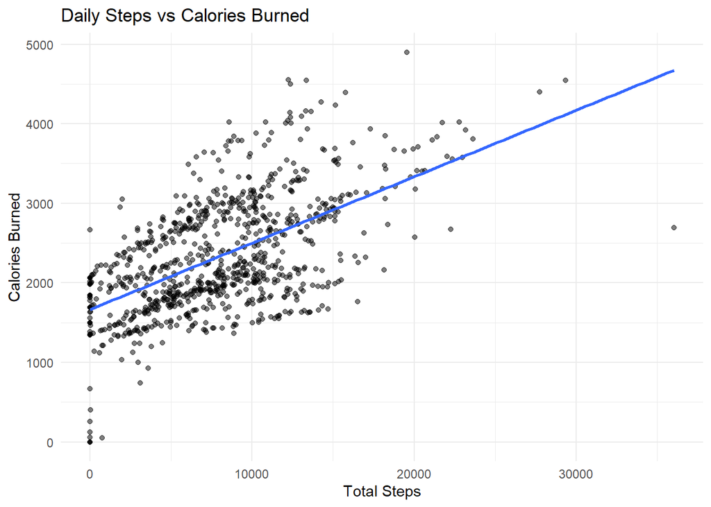

```r
ggplot(activity_sleep, aes(x = total_steps, y = calories)) +
  geom_point(alpha = 0.5) +
  geom_smooth(method = "lm", se = FALSE) +
  labs(
    title = "Daily Steps vs Calories Burned",
    x = "Total Steps",
    y = "Calories Burned"
  ) +
  theme_minimal()
```